# Module 1: Introduction to Statistics

Statistics Course

2026-02-10

# Introduction to Statistics

## Overview

In this module, we explore fundamental statistical concepts including: - Statistics and Data Analysis - Measures of Central Tendency - Measures of Dispersion - Moments, Skewness, and Kurtosis

We’ll use the `nycflights13` dataset to demonstrate these concepts with real-world data.

## Data Preparation

First, let’s load the necessary libraries and explore the NYC flights dataset:

```r
# Install packages if needed (uncomment to run)
# install.packages(c("nycflights13", "tidyverse", "moments"))

library(nycflights13)
library(dplyr)
library(ggplot2)
library(tidyr)
library(moments)

# Load the flights dataset
data(flights)

# Display basic information
head(flights)
```

```
## # A tibble: 6 × 19
##    year month   day dep_time sched_dep_time dep_delay arr_time sched_arr_time
##   <int> <int> <int>    <int>          <int>     <dbl>    <int>          <int>
## 1  2013     1     1      517            515         2      830            819
## 2  2013     1     1      533            529         4      850            830
## 3  2013     1     1      542            540         2      923            850
## 4  2013     1     1      544            545        -1     1004           1022
## 5  2013     1     1      554            600        -6      812            837
## 6  2013     1     1      554            558        -4      740            728
## # ℹ 11 more variables: arr_delay <dbl>, carrier <chr>, flight <int>,
## #   tailnum <chr>, origin <chr>, dest <chr>, air_time <dbl>, distance <dbl>,
## #   hour <dbl>, minute <dbl>, time_hour <dttm>
```

```r
cat("\nDataset dimensions:", nrow(flights), "rows x", ncol(flights), "columns\n")
```

```
##
## Dataset dimensions: 336776 rows x 19 columns
```

```r
cat("\nColumn names:\n")
```

```
##
## Column names:
```

```r
print(names(flights))
```

```
##  [1] "year"           "month"          "day"            "dep_time"
##  [5] "sched_dep_time" "dep_delay"      "arr_time"       "sched_arr_time"
##  [9] "arr_delay"      "carrier"        "flight"         "tailnum"
## [13] "origin"         "dest"           "air_time"       "distance"
## [17] "hour"           "minute"         "time_hour"
```

## 1. Statistics and Data Analysis

Statistics involves collecting, analyzing, and interpreting data to understand patterns and relationships.

### What is Statistical Data Analysis?

Statistical data analysis helps us: - Describe the characteristics of data - Make inferences about populations - Test hypotheses - Predict future trends

### Example: Airline Delay Analysis

Let’s analyze departure delays across different airlines:

```r
# Create a summary of airlines in the dataset
airline_summary <- flights %>%
  group_by(carrier) %>%
  summarise(
    n_flights = n(),
    avg_delay = mean(dep_delay, na.rm = TRUE),
    max_delay = max(dep_delay, na.rm = TRUE),
    min_delay = min(dep_delay, na.rm = TRUE)
  ) %>%
  arrange(desc(avg_delay))

print(airline_summary)
```

```
## # A tibble: 16 × 5
##    carrier n_flights avg_delay max_delay min_delay
##    <chr>       <int>     <dbl>     <dbl>     <dbl>
##  1 F9            685     20.2        853       -27
##  2 EV          54173     20.0        548       -32
##  3 YV            601     19.0        387       -16
##  4 FL           3260     18.7        602       -22
##  5 WN          12275     17.7        471       -13
##  6 9E          18460     16.7        747       -24
##  7 B6          54635     13.0        502       -43
##  8 VX           5162     12.9        653       -20
##  9 OO             32     12.6        154       -14
## 10 UA          58665     12.1        483       -20
## 11 MQ          26397     10.6       1137       -26
## 12 DL          48110      9.26       960       -33
## 13 AA          32729      8.59      1014       -24
## 14 AS            714      5.80       225       -21
## 15 HA            342      4.90      1301       -16
## 16 US          20536      3.78       500       -19
```

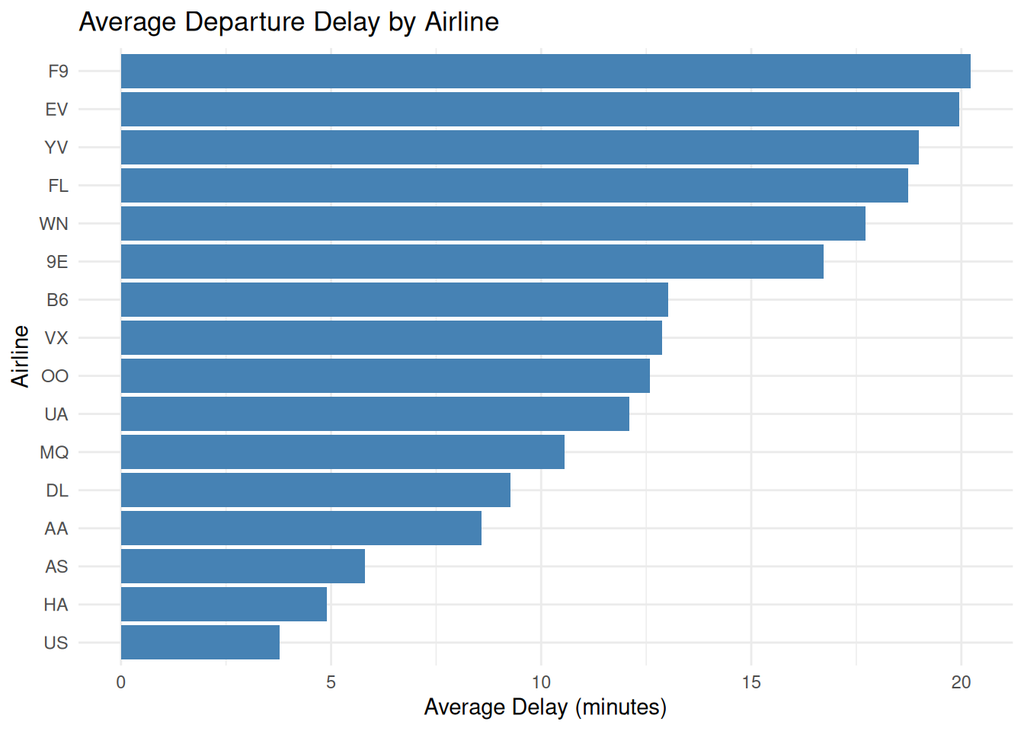

```r
# Visualize average delays by airline
ggplot(airline_summary, aes(x = reorder(carrier, avg_delay), y = avg_delay)) +
  geom_col(fill = "steelblue") +
  coord_flip() +
  labs(title = "Average Departure Delay by Airline",
       x = "Airline",
       y = "Average Delay (minutes)") +
  theme_minimal()
```

## 2. Measures of Central Tendency

Central tendency measures describe the “center” or typical value of a dataset.

### Types of Central Tendency

**2.1 Mean (Average)**

The arithmetic mean is the sum of all values divided by the count of values.

$$\bar{x} = \frac{1}{n}\sum_{i=1}^{n}
x_i$$

```r
# Calculate mean departure delay
mean_delay <- mean(flights$dep_delay, na.rm = TRUE)
cat("Mean departure delay:", round(mean_delay, 2), "minutes\n")
```

```
## Mean departure delay: 12.64 minutes
```

```r
# By month
mean_by_month <- flights %>%
  group_by(month) %>%
  summarise(mean_delay = mean(dep_delay, na.rm = TRUE),
            .groups = 'drop')

print(mean_by_month)
```

```
## # A tibble: 12 × 2
##    month mean_delay
##    <int>      <dbl>
##  1     1      10.0
##  2     2      10.8
##  3     3      13.2
##  4     4      13.9
##  5     5      13.0
##  6     6      20.8
##  7     7      21.7
##  8     8      12.6
##  9     9       6.72
## 10    10       6.24
## 11    11       5.44
## 12    12      16.6
```

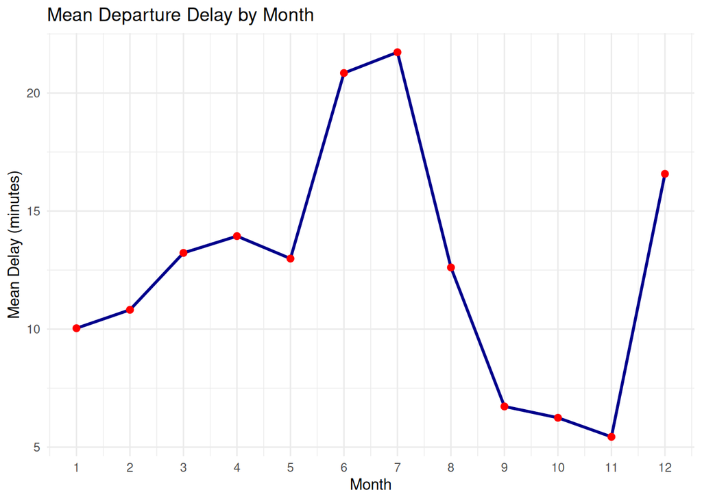

```r
# Visualize mean delays by month
ggplot(mean_by_month, aes(x = month, y = mean_delay)) +
  geom_line(color = "darkblue", size = 1) +
  geom_point(color = "red", size = 2) +
  labs(title = "Mean Departure Delay by Month",
       x = "Month",
       y = "Mean Delay (minutes)") +
  theme_minimal() +
  scale_x_continuous(breaks = 1:12)
```

**2.2 Median (Middle Value)**

The median is the middle value when data is sorted. It divides the dataset into two equal halves.

```r
# Calculate median departure delay
median_delay <- median(flights$dep_delay, na.rm = TRUE)
cat("Median departure delay:", median_delay, "minutes\n")
```

```
## Median departure delay: -2 minutes
```

```r
# Compare mean vs median for each month
comparison <- flights %>%
  group_by(month) %>%
  summarise(
    mean_delay = mean(dep_delay, na.rm = TRUE),
    median_delay = median(dep_delay, na.rm = TRUE),
    .groups = 'drop'
  )

print(comparison)
```

```
## # A tibble: 12 × 3
##    month mean_delay median_delay
##    <int>      <dbl>        <dbl>
##  1     1      10.0            -2
##  2     2      10.8            -2
##  3     3      13.2            -1
##  4     4      13.9            -2
##  5     5      13.0            -1
##  6     6      20.8             0
##  7     7      21.7             0
##  8     8      12.6            -1
##  9     9       6.72           -3
## 10    10       6.24           -3
## 11    11       5.44           -3
## 12    12      16.6             0
```

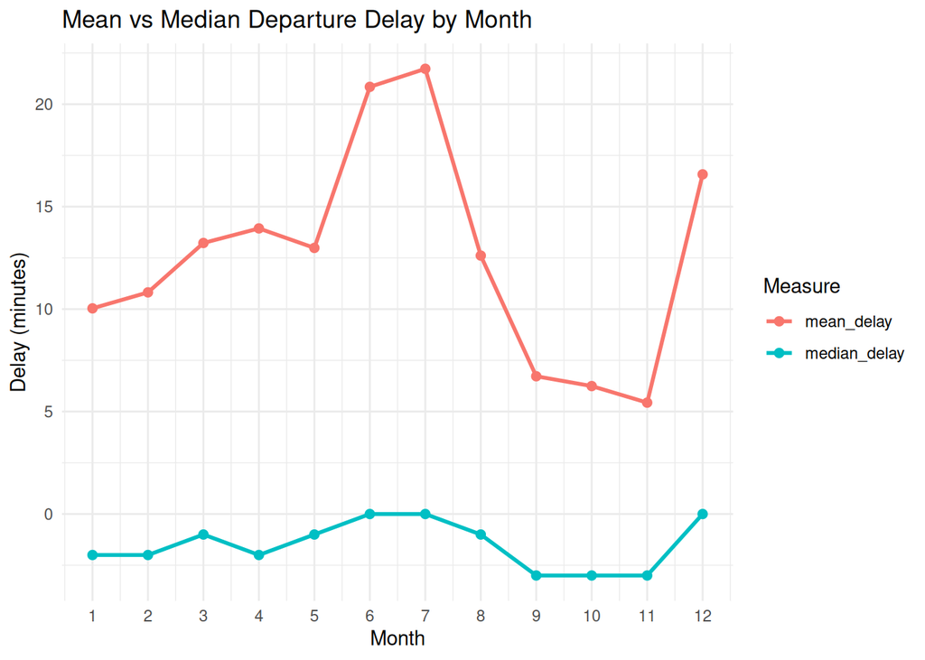

```r
# Visualize comparison
comparison_long <- comparison %>%
  pivot_longer(cols = c(mean_delay, median_delay),
               names_to = "measure",
               values_to = "delay")

ggplot(comparison_long, aes(x = month, y = delay, color = measure)) +
  geom_line(size = 1) +
  geom_point(size = 2) +
  labs(title = "Mean vs Median Departure Delay by Month",
       x = "Month",
       y = "Delay (minutes)",
       color = "Measure") +
  theme_minimal() +
  scale_x_continuous(breaks = 1:12)
```

**2.3 Mode (Most Frequent Value)**

The mode is the value that appears most frequently in the dataset.

```r
# Calculate mode
calculate_mode <- function(x) {
  freq <- table(x)
  as.numeric(names(freq)[which.max(freq)])
}

# Mode is often used for categorical data
mode_origin <- calculate_mode(flights$origin)
cat("Mode of origin:", mode_origin, "\n")
```

```
## Mode of origin: NA
```

```r
# Frequency of origins
origin_freq <- flights %>%
  group_by(origin) %>%
  summarise(count = n(), .groups = 'drop') %>%
  arrange(desc(count))

print(origin_freq)
```

```
## # A tibble: 3 × 2
##   origin  count
##   <chr>   <int>
## 1 EWR    120835
## 2 JFK    111279
## 3 LGA    104662
```

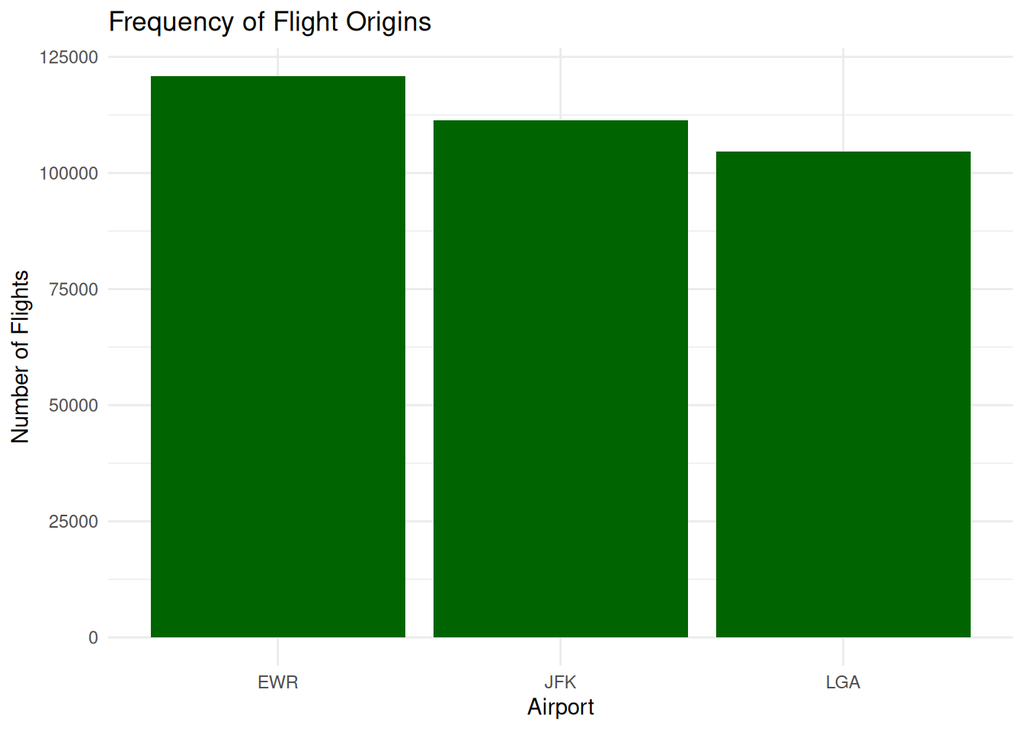

```r
# Visualize
ggplot(origin_freq, aes(x = reorder(origin, -count), y = count)) +
  geom_col(fill = "darkgreen") +
  labs(title = "Frequency of Flight Origins",
       x = "Airport",
       y = "Number of Flights") +
  theme_minimal()
```

**Comparison of Central Tendency Measures:**

```r
# Overall comparison
cat("=== Central Tendency Measures for Departure Delay ===\n")
```

```
## === Central Tendency Measures for Departure Delay ===
```

```r
cat("Mean:  ", round(mean(flights$dep_delay, na.rm = TRUE), 2), "minutes\n")
```

```
## Mean:   12.64 minutes
```

```r
cat("Median:", median(flights$dep_delay, na.rm = TRUE), "minutes\n")
```

```
## Median: -2 minutes
```

```r
cat("Mode:  ", calculate_mode(round(flights$dep_delay)), "minutes\n")
```

```
## Mode:   -5 minutes
```

```r
# Summary statistics
cat("\n=== Summary Statistics ===\n")
```

```
##
## === Summary Statistics ===
```

```r
print(summary(flights$dep_delay))
```

```
##    Min. 1st Qu.  Median    Mean 3rd Qu.    Max.    NA's
##  -43.00   -5.00   -2.00   12.64   11.00 1301.00    8255
```

## 3. Measures of Dispersion

Dispersion measures describe the spread or variability of data around the center.

### 3.1 Range

Range is the difference between the maximum and minimum values.

$$\text{Range} = \max(x) -
\min(x)$$

```r
range_delay <- max(flights$dep_delay, na.rm = TRUE) - min(flights$dep_delay, na.rm = TRUE)
cat("Range of departure delay:", range_delay, "minutes\n")
```

```
## Range of departure delay: 1344 minutes
```

```r
cat("Min delay:", min(flights$dep_delay, na.rm = TRUE), "minutes\n")
```

```
## Min delay: -43 minutes
```

```r
cat("Max delay:", max(flights$dep_delay, na.rm = TRUE), "minutes\n")
```

```
## Max delay: 1301 minutes
```

### 3.2 Variance

Variance measures the average squared deviation from the mean.

$$s^2 = \frac{1}{n}\sum_{i=1}^{n} (x_i -
\bar{x})^2$$

```r
var_delay <- var(flights$dep_delay, na.rm = TRUE)
cat("Variance of departure delay:", round(var_delay, 2), "\n")
```

```
## Variance of departure delay: 1616.85
```

```r
# By airline
var_by_airline <- flights %>%
  group_by(carrier) %>%
  summarise(
    variance = var(dep_delay, na.rm = TRUE),
    n = n(),
    .groups = 'drop'
  ) %>%
  arrange(desc(variance))

print(var_by_airline)
```

```
## # A tibble: 16 × 3
##    carrier variance     n
##    <chr>      <dbl> <int>
##  1 HA         5492.   342
##  2 F9         3406.   685
##  3 FL         2773.  3260
##  4 YV         2418.   601
##  5 EV         2167. 54173
##  6 9E         2107. 18460
##  7 VX         2008.  5162
##  8 WN         1879. 12275
##  9 OO         1855.    32
## 10 DL         1579. 48110
## 11 MQ         1535. 26397
## 12 B6         1483. 54635
## 13 AA         1395. 32729
## 14 UA         1276. 58665
## 15 AS          984.   714
## 16 US          787. 20536
```

### 3.3 Standard Deviation

Standard deviation is the square root of variance, expressing dispersion in original units.

$$s = \sqrt{\frac{1}{n}\sum_{i=1}^{n} (x_i
- \bar{x})^2}$$

```r
sd_delay <- sd(flights$dep_delay, na.rm = TRUE)
cat("Standard deviation of departure delay:", round(sd_delay, 2), "minutes\n")
```

```
## Standard deviation of departure delay: 40.21 minutes
```

```r
# By month
sd_by_month <- flights %>%
  group_by(month) %>%
  summarise(
    sd_delay = sd(dep_delay, na.rm = TRUE),
    mean_delay = mean(dep_delay, na.rm = TRUE),
    .groups = 'drop'
  )

print(sd_by_month)
```

```
## # A tibble: 12 × 3
##    month sd_delay mean_delay
##    <int>    <dbl>      <dbl>
##  1     1     36.4      10.0
##  2     2     36.3      10.8
##  3     3     40.1      13.2
##  4     4     43.0      13.9
##  5     5     39.4      13.0
##  6     6     51.5      20.8
##  7     7     51.6      21.7
##  8     8     37.7      12.6
##  9     9     35.6       6.72
## 10    10     29.7       6.24
## 11    11     27.6       5.44
## 12    12     41.9      16.6
```

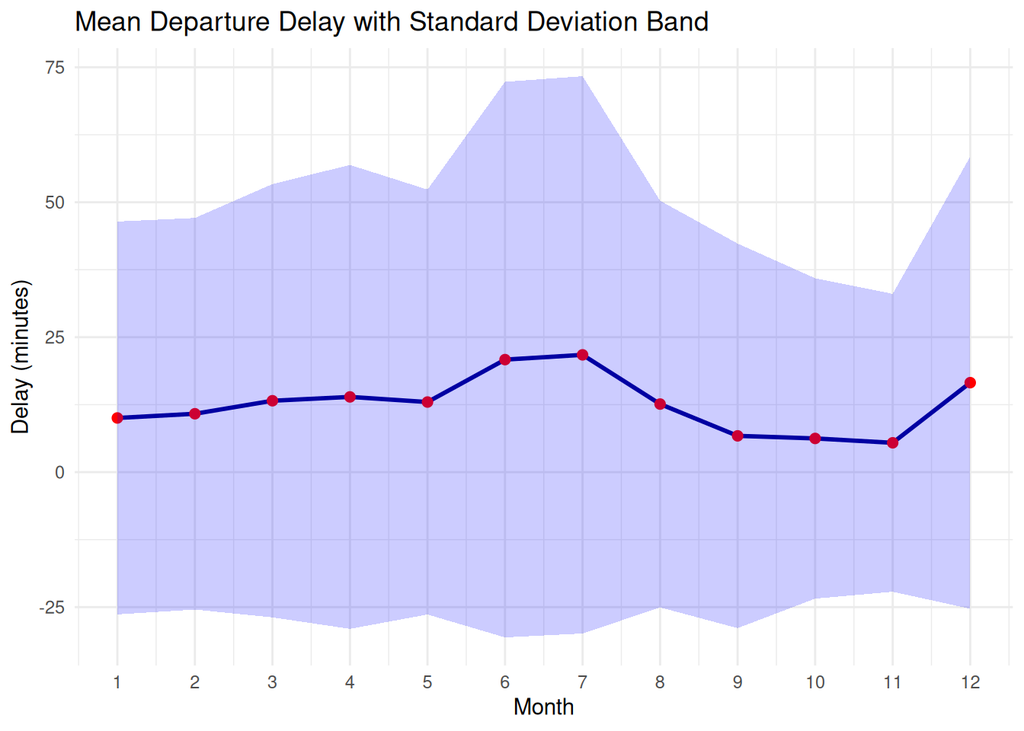

```r
# Visualize with confidence bands
ggplot(sd_by_month, aes(x = month, y = mean_delay)) +
  geom_line(color = "darkblue", size = 1) +
  geom_point(color = "red", size = 2) +
  geom_ribbon(aes(ymin = mean_delay - sd_delay, ymax = mean_delay + sd_delay),
              alpha = 0.2, fill = "blue") +
  labs(title = "Mean Departure Delay with Standard Deviation Band",
       x = "Month",
       y = "Delay (minutes)") +
  theme_minimal() +
  scale_x_continuous(breaks = 1:12)
```

### 3.4 Quartiles and Interquartile Range (IQR)

Quartiles divide the data into four equal parts.

```r
# Calculate quartiles
q1 <- quantile(flights$dep_delay, 0.25, na.rm = TRUE)
q2 <- quantile(flights$dep_delay, 0.50, na.rm = TRUE)  # Median
q3 <- quantile(flights$dep_delay, 0.75, na.rm = TRUE)
iqr <- q3 - q1

cat("Q1 (25th percentile):", q1, "\n")
```

```
## Q1 (25th percentile): -5
```

```r
cat("Q2 (50th percentile/Median):", q2, "\n")
```

```
## Q2 (50th percentile/Median): -2
```

```r
cat("Q3 (75th percentile):", q3, "\n")
```

```
## Q3 (75th percentile): 11
```

```r
cat("Interquartile Range (IQR):", iqr, "\n")
```

```
## Interquartile Range (IQR): 16
```

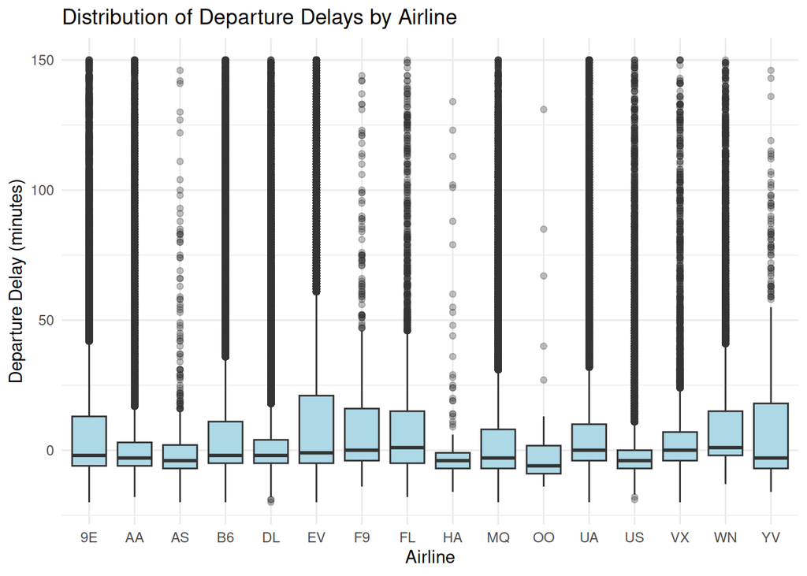

```r
# Box plot by airline
ggplot(flights, aes(x = carrier, y = dep_delay)) +
  geom_boxplot(fill = "lightblue", outlier.alpha = 0.3) +
  labs(title = "Distribution of Departure Delays by Airline",
       x = "Airline",
       y = "Departure Delay (minutes)") +
  theme_minimal() +
  ylim(-20, 150)  # Limit y-axis for better visualization
```

### 3.5 Coefficient of Variation

CV measures relative variability as a percentage of the mean.

$$CV = \frac{s}{\bar{x}} \times
100\%$$

```r
mean_delay <- mean(flights$dep_delay, na.rm = TRUE)
sd_delay <- sd(flights$dep_delay, na.rm = TRUE)
cv <- (sd_delay / mean_delay) * 100

cat("Coefficient of Variation:", round(cv, 2), "%\n")
```

```
## Coefficient of Variation: 318.14 %
```

```r
# By airline
cv_by_airline <- flights %>%
  group_by(carrier) %>%
  summarise(
    mean = mean(dep_delay, na.rm = TRUE),
    sd = sd(dep_delay, na.rm = TRUE),
    cv = (sd / mean) * 100,
    .groups = 'drop'
  ) %>%
  arrange(desc(cv))

print(cv_by_airline)
```

```
## # A tibble: 16 × 4
##    carrier  mean    sd    cv
##    <chr>   <dbl> <dbl> <dbl>
##  1 HA       4.90  74.1 1512.
##  2 US       3.78  28.1  742.
##  3 AS       5.80  31.4  540.
##  4 AA       8.59  37.4  435.
##  5 DL       9.26  39.7  429.
##  6 MQ      10.6   39.2  371.
##  7 VX      12.9   44.8  348.
##  8 OO      12.6   43.1  342.
##  9 B6      13.0   38.5  296.
## 10 UA      12.1   35.7  295.
## 11 F9      20.2   58.4  289.
## 12 FL      18.7   52.7  281.
## 13 9E      16.7   45.9  274.
## 14 YV      19.0   49.2  259.
## 15 WN      17.7   43.3  245.
## 16 EV      20.0   46.6  233.
```

## 4. Moments, Skewness, and Kurtosis

### 4.1 Moments

Moments describe the shape and characteristics of a distribution.

**Raw Moments:** $m_r = \frac{1}{n}\sum_{i=1}^{n} (x_i)^r$

**Central Moments:** $\mu_r = \frac{1}{n}\sum_{i=1}^{n} (x_i - \bar{x})^r$

```r
# Calculate moments
m1 <- mean(flights$dep_delay, na.rm = TRUE)
m2 <- mean((flights$dep_delay - m1)^2, na.rm = TRUE)
m3 <- mean((flights$dep_delay - m1)^3, na.rm = TRUE)
m4 <- mean((flights$dep_delay - m1)^4, na.rm = TRUE)

cat("First moment (Mean):", round(m1, 2), "\n")
```

```
## First moment (Mean): 12.64
```

```r
cat("Second moment (Variance):", round(m2, 2), "\n")
```

```
## Second moment (Variance): 1616.84
```

```r
cat("Third moment:", round(m3, 2), "\n")
```

```
## Third moment: 312227.6
```

```r
cat("Fourth moment:", round(m4, 2), "\n")
```

```
## Fourth moment: 122734482
```

### 4.2 Skewness

Skewness measures the asymmetry of the distribution.

$$\text{Skewness} =
\frac{\mu_3}{s^3}$$

- **Skewness = 0**: Symmetric distribution
- **Skewness > 0**: Right-skewed (positively skewed)
- **Skewness < 0**: Left-skewed (negatively skewed)

```r
# Calculate skewness
skewness_value <- skewness(flights$dep_delay, na.rm = TRUE)
cat("Skewness of departure delay:", round(skewness_value, 3), "\n")
```

```
## Skewness of departure delay: 4.803
```

```r
if (skewness_value > 0.5) {
  cat("Interpretation: Right-skewed (positive skew) distribution\n")
} else if (skewness_value < -0.5) {
  cat("Interpretation: Left-skewed (negative skew) distribution\n")
} else {
  cat("Interpretation: Approximately symmetric distribution\n")
}
```

```
## Interpretation: Right-skewed (positive skew) distribution
```

```r
# Skewness by month
skewness_by_month <- flights %>%
  group_by(month) %>%
  summarise(
    skewness = skewness(dep_delay, na.rm = TRUE),
    .groups = 'drop'
  )

print(skewness_by_month)
```

```
## # A tibble: 12 × 2
##    month skewness
##    <int>    <dbl>
##  1     1     6.84
##  2     2     5.28
##  3     3     4.38
##  4     4     4.62
##  5     5     4.47
##  6     6     3.94
##  7     7     3.71
##  8     8     3.91
##  9     9     6.27
## 10    10     5.02
## 11    11     6.04
## 12    12     4.69
```

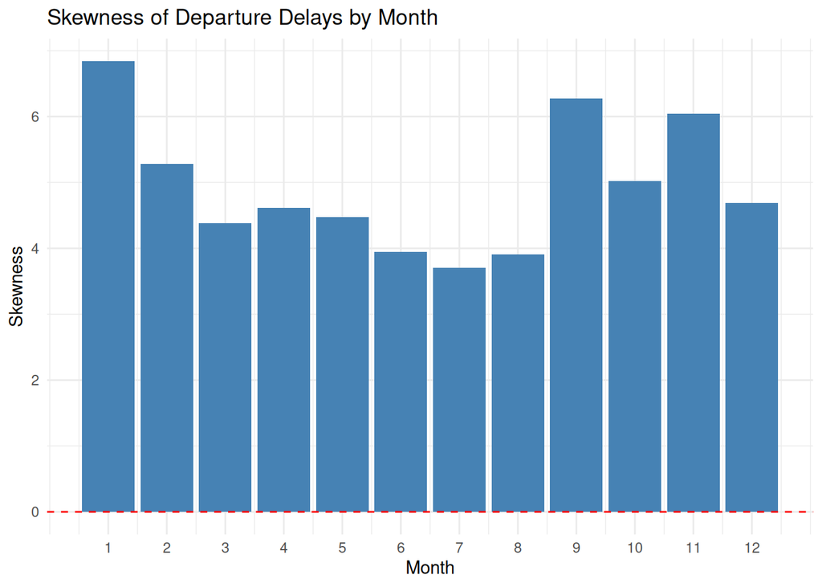

```r
# Visualize
ggplot(skewness_by_month, aes(x = month, y = skewness)) +
  geom_col(fill = "steelblue") +
  geom_hline(yintercept = 0, linetype = "dashed", color = "red") +
  labs(title = "Skewness of Departure Delays by Month",
       x = "Month",
       y = "Skewness") +
  theme_minimal() +
  scale_x_continuous(breaks = 1:12)
```

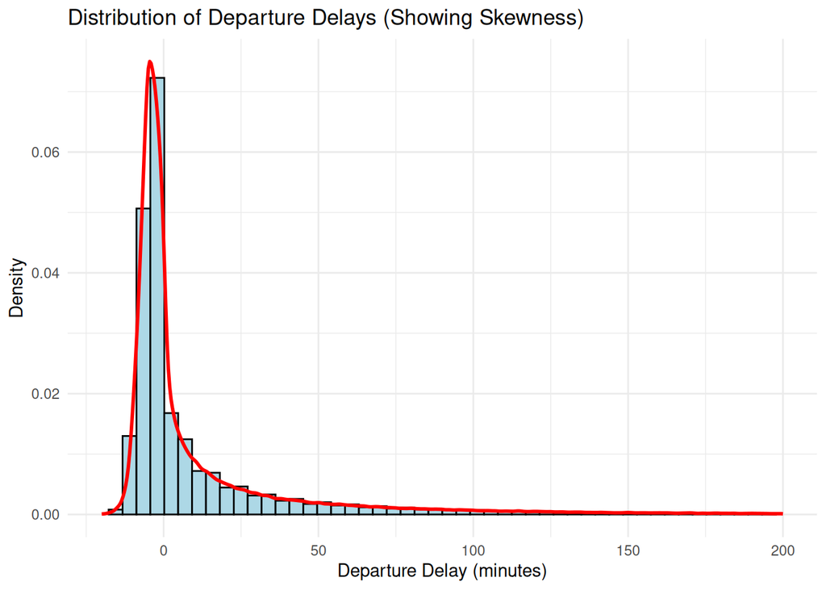

```r
# Distribution histogram with density curve
ggplot(flights, aes(x = dep_delay)) +
  geom_histogram(aes(y = ..density..), bins = 50, fill = "lightblue", color = "black") +
  geom_density(color = "red", size = 1) +
  labs(title = "Distribution of Departure Delays (Showing Skewness)",
       x = "Departure Delay (minutes)",
       y = "Density") +
  theme_minimal() +
  xlim(-20, 200)
```

### 4.3 Kurtosis

Kurtosis measures the “tailedness” or peakedness of the distribution.

$$\text{Kurtosis} = \frac{\mu_4}{s^4} -
3$$

- **Excess Kurtosis = 0**: Mesokurtic (Normal distribution)
- **Excess Kurtosis > 0**: Leptokurtic (Heavy tails, sharp peak)
- **Excess Kurtosis < 0**: Platykurtic (Light tails, flat peak)

```r
# Calculate kurtosis (excess kurtosis)
kurtosis_value <- kurtosis(flights$dep_delay, na.rm = TRUE)
cat("Excess Kurtosis of departure delay:", round(kurtosis_value, 3), "\n")
```

[output not shown]

```r
if (kurtosis_value > 0) {
  cat("Interpretation: Leptokurtic - Heavy tails with sharp peak\n")
} else if (kurtosis_value < 0) {
  cat("Interpretation: Platykurtic - Light tails with flat peak\n")
} else {
  cat("Interpretation: Mesokurtic - Similar to normal distribution\n")
}
```

```
## Interpretation: Leptokurtic - Heavy tails with sharp peak
```

```r
# Kurtosis by month
kurtosis_by_month <- flights %>%
  group_by(month) %>%
  summarise(
    kurtosis = kurtosis(dep_delay, na.rm = TRUE),
    .groups = 'drop'
  )

print(kurtosis_by_month)
```

```
## # A tibble: 12 × 2
##    month kurtosis
##    <int>    <dbl>
##  1     1    127.
##  2     2     59.5
##  3     3     36.2
##  4     4     43.1
##  5     5     39.1
##  6     6     32.2
##  7     7     26.0
##  8     8     24.1
##  9     9     69.8
## 10    10     42.7
## 11    11     72.9
## 12    12     46.6
```

[figure not shown]

```r
# Visualize
ggplot(kurtosis_by_month, aes(x = month, y = kurtosis)) +
  geom_col(fill = "darkgreen") +
  geom_hline(yintercept = 0, linetype = "dashed", color = "red") +
  labs(title = "Kurtosis of Departure Delays by Month",
       x = "Month",
       y = "Excess Kurtosis") +
  theme_minimal() +
  scale_x_continuous(breaks = 1:12)
```

## 5. Hypothesis Test: On-time departures predict on-time arrivals

We test the hypothesis: “Flights that left within 5 minutes of their scheduled departure arrived within 5 minutes of their scheduled arrival.” Below we filter the data, create logical indicators for leaving/arriving within ±5 minutes, show contingency counts and proportions, run an appropriate test of association (chi-squared or Fisher’s exact), compute conditional probabilities, plot the results, and provide a brief interpretation.

```r
library(dplyr)
library(ggplot2)

# Filter and create indicators
fl_ht <- flights %>%
  filter(!is.na(dep_delay), !is.na(arr_delay)) %>%
  mutate(
    left_on_time = abs(dep_delay) <= 5,
    arrived_on_time = abs(arr_delay) <= 5
  )

# Contingency table and row proportions
tab <- table(Left = fl_ht$left_on_time, Arrived = fl_ht$arrived_on_time)
tab
```

```
##        Arrived
## Left     FALSE   TRUE
##   FALSE 144648  23631
##   TRUE  124330  34737
```

```r
prop_tab <- prop.table(tab, margin = 1)
round(prop_tab, 3)
```

```
##        Arrived
## Left    FALSE  TRUE
##   FALSE 0.860 0.140
##   TRUE  0.782 0.218
```

```r
# Statistical test: chi-squared if expected counts are large enough, otherwise Fisher's exact
# Use suppressWarnings when computing expected to avoid extra output if assumptions borderline
expected <- suppressWarnings(chisq.test(tab))$expected
use_fisher <- any(expected < 5)

if (use_fisher) {
  test_result <- fisher.test(tab)
} else {
  test_result <- chisq.test(tab)
}
test_result
```

```
##
##    Pearson's Chi-squared test with Yates' continuity correction
##
## data:  tab
## X-squared = 3390.9, df = 1, p-value < 2.2e-16
```

```r
# Conditional probabilities
P_arrive_if_left <- prop_tab["TRUE", "TRUE"]
P_arrive_if_not_left <- prop_tab["FALSE", "TRUE"]
cat(sprintf("P(arrived_on_time | left_on_time) = %.3f\n", P_arrive_if_left))
```

```
## P(arrived_on_time | left_on_time) = 0.218
```

```r
cat(sprintf("P(arrived_on_time | NOT left_on_time) = %.3f\n", P_arrive_if_not_left))
```

```
## P(arrived_on_time | NOT left_on_time) = 0.140
```

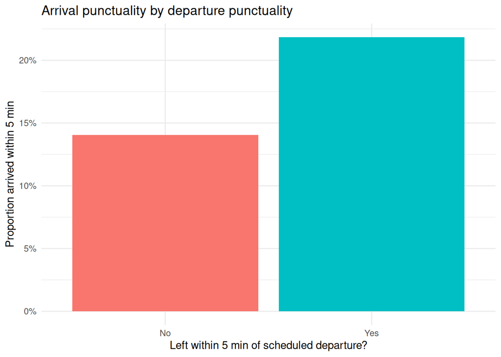

```r
# Visualization: proportion arrived on time by whether flight left on time
viz_df <- fl_ht %>%
  group_by(left_on_time) %>%
  summarize(n = n(), prop_arrived_on_time = mean(arrived_on_time), .groups = "drop")

ggplot(viz_df, aes(x = factor(left_on_time), y = prop_arrived_on_time, fill = factor(left_on_time))) +
  geom_col() +
  scale_y_continuous(labels = scales::percent_format(accuracy = 1)) +
  labs(x = "Left within 5 min of scheduled departure?", y = "Proportion arrived within 5 min",
       title = "Arrival punctuality by departure punctuality") +
  theme_minimal() +
  scale_x_discrete(labels = c("FALSE" = "No", "TRUE" = "Yes")) +
  guides(fill = "none")
```

**Interpretation (how to read results):**

- The contingency table shows counts of flights that arrived on time or not, split by whether they left on time.
- The chi-squared (or Fisher) test reports whether there is evidence of association between departure punctuality and arrival punctuality. A small p-value (e.g., < 0.05) indicates an association.
- The conditional probabilities P(arrived_on_time | left_on_time) and P(arrived_on_time | NOT left_on_time) give practical measures of how predictive departure punctuality is for arrival punctuality.

Note: This is observational data; association does not imply causation.

## 6. Summary: Complete Statistical Profile

Let’s create a comprehensive summary of all statistical measures:

```r
# Comprehensive statistical summary
summary_stats <- data.frame(
  Measure = c("Mean", "Median", "Std Dev", "Variance", "Range", "Q1", "Q3", "IQR",
              "Skewness", "Kurtosis", "CV (%)"),
  Value = c(
    round(mean(flights$dep_delay, na.rm = TRUE), 2),
    median(flights$dep_delay, na.rm = TRUE),
    round(sd(flights$dep_delay, na.rm = TRUE), 2),
    round(var(flights$dep_delay, na.rm = TRUE), 2),
    max(flights$dep_delay, na.rm = TRUE) - min(flights$dep_delay, na.rm = TRUE),
    quantile(flights$dep_delay, 0.25, na.rm = TRUE),
    quantile(flights$dep_delay, 0.75, na.rm = TRUE),
    quantile(flights$dep_delay, 0.75, na.rm = TRUE) - quantile(flights$dep_delay, 0.25, na.rm = TRUE),
    round(skewness(flights$dep_delay, na.rm = TRUE), 3),
    round(kurtosis(flights$dep_delay, na.rm = TRUE), 3),
    round((sd(flights$dep_delay, na.rm = TRUE) / mean(flights$dep_delay, na.rm = TRUE)) * 100, 2)
  )
)

cat("=== COMPLETE STATISTICAL SUMMARY ===\n")
```

```
## === COMPLETE STATISTICAL SUMMARY ===
```

```r
print(summary_stats)
```

```
##     Measure    Value
## 1      Mean   12.640
## 2    Median   -2.000
## 3   Std Dev   40.210
## 4  Variance 1616.850
## 5     Range 1344.000
## 6        Q1   -5.000
## 7        Q3   11.000
## 8       IQR   16.000
## 9  Skewness    4.803
## 10 Kurtosis   46.949
## 11   CV (%)  318.140
```

```r
# Export summary
write.csv(summary_stats, "output/statistical_summary.csv", row.names = FALSE)
cat("\nSummary saved to output/statistical_summary.csv\n")
```

```
##
## Summary saved to output/statistical_summary.csv
```

## Conclusion

This module has covered the fundamental concepts of statistics:

1. **Statistics and Data Analysis** - Understanding data patterns and relationships
2. **Measures of Central Tendency** - Mean, Median, and Mode describe typical values
3. **Measures of Dispersion** - Range, Variance, SD, and IQR describe spread
4. **Moments, Skewness, and Kurtosis** - Describe distribution shape and characteristics

These tools form the foundation for more advanced statistical methods and hypothesis testing.

## Exercises

1. **Arrival Delay Analysis**: Calculate the mean, median, and standard deviation for `arr_delay` (arrival delays). How do these compare to the statistics for departure delays calculated earlier?
2. **Carrier Variability**: Which airline carrier has the most consistent arrival times? Calculate the standard deviation of `arr_delay` for each carrier and identify the one with the lowest value.
3. **Speed Distribution**: Create a new variable called `speed_mph` by calculating `distance / (air_time / 60)`.
   - Calculate the mean and median speed.
   - Visualize the distribution of flight speeds using a histogram.
   - Is the distribution symmetric or skewed? Calculate the skewness to confirm.
4. **Interval Data Statistics**: Convert the `dep_delay` variable from point data to interval data (grouped data) by creating bins (e.g., using `cut()`).
   - Redo the statistics (mean, standard deviation, and quartiles).
   - Compare the results with the statistics calculated from the original point data.
5. **Random Variables and Distributions**: Let $X$ be the random variable representing departure delay.
   - Calculate the expected value $E[X]$ and variance $Var(X)$ from the data.
   - Visualize the probability density function (PDF) of $X$.
   - Based on the shape, skewness, and kurtosis, discuss which theoretical distribution might fit the data.
6. **On-time Performance Test**: Conduct a hypothesis test to check if there is an association between the origin airport (`origin`) and whether a flight arrives on time (within 5 minutes of scheduled arrival).
   - Create a contingency table.
   - Run a Chi-squared test.
   - Interpret the results.

## References

- Wickham, H. (2016). ggplot2: Elegant Graphics for Data Analysis.
- James, G., Witten, D., Hastie, T., & Tibshirani, R. (2013). An Introduction to Statistical Learning.
- nycflights13 R Package: https://github.com/hadley/nycflights13